# How to run locally a c-model

7.0.0  
How to run locally a c-model

- [ Index ]
- Purpose
- C-base environment
  - Retrieve the X86 C library files
  - Build the test application
  - Update the test application source tree with a new c-model
  - Test code
- Python-base environment
  - Overview
  - Installation
  - Getting started
  - Examples
  - Typical errors

# How to run locally a c-model

X-CUBE-AI Expansion Package

r1.0

AI PLATFORM r7.0.0 (Embedded Inference Client API 1.1.0)

Command Line Interface r1.5.1

# Purpose

This article explains how to run locally the generated c-model to:

- enhance an end-user validation process with a large data set including the specific pre and post processing functions with the X-CUBE-AI inference run-time.
- integrate a X-CUBE-AI validation step in a CI/CD flow w/o STM32 board

To cover different constraints or phases of the project, two environments are considered:

- C-base environment providing an easy way to test a complete solution with the pre-post process functions written in C. Ready to be deployed/integrated in a STM32 project.
- Python-base environment allowing to address a flexible and complete environment to design, to evaluate and to test different AI-base solutions.

> `%X_CUBE_AI_DIR%` indicates the location where the X-CUBE-AI pack is installed.

# C-base environment

This environment is based on the same X86 C libraries which are used to perform the built-in validation flow. So, the main prerequisite is to have a compatible C/C++ tool chain to be able to link the final application with them. Note that in Windows® development environment, a MingGW-W64 tool chain is available in X-CUBE-AI pack, including the GNU Make utility.

Following source tree is used to illustrate this how-to. `cubeai_lib_XX` directory contains the X-CUBE-AI X86 C library files to build the generated c-model files in `model` directory.

```c
<root_project>
        |- makefile
        |_ main.c                  /* entry point,  */
        |_ *.c/*.h                 /* extra/user test framework files */
        |
        |_ model
        |   |_ network.c/.h        /* generated c-model files */
        |   |_ network_data.c/.h
        |   |_ network_config.h
        |
        \_ cubeai_lib_XX
            |_ include             /* X-CUBE-AI header files */
            |_ lib                 /* Libraries */
```

## Retrieve the X86 C library files

By OS, the expected X86 library files are located in:

```
%X_CUBE_AI_DIR%/Utilities/%OS%/targets/common/EmbedNets/tools/inspector/workspace/
```

All content of the `include` folder can be directly copied in `<root_project>/cube_ai_lib_XX/inlude`. Idem for the content of `lib` in `<root_project>/cube_ai_lib_XX/lib`. Note the the share libraries (`*.dll` or `.so`) are not necessary.

## Build the test application

```
AI_LIB_DIR = $(root_project)/cubeai_lib_XX
...
CFLAGS += $(root_project)/model

CFLAGS += -std=c99
CFLAGS += -I$(AI_LIB_DIR)/include

LIBS = -L$(AI_LIB_DIR)/lib/static -lruntime -lst_cmsis_nn -lcmsis_nn -lx86_cmsis -lm
```

## Update the test application source tree with a new c-model

The `generate` command can be used with the `--output/-o` option to indicate the location of the generated files.

```powershell
$ stm32ai generate -m <my_model> <my_options> -o %root_project%/model/
```

## Test code

There is no difference between the embedded inference API used for a STM32 application and for the X86 test application. Setup/init sequence and the calls of the `ai_<network>_XXX()` functions are the same.

```cpp
#include <stdio.h>
#include <stdlib.h>
#include <time.h>
#include <string.h>

#include "network.h"
#include "network_data.h"

/**
 * @brief Statically allocate buffers.
 * @note Buffers can be dynamically allocated using malloc and size information
 * given by the report in ai_network_get_info().
 */
ai_u8 activations[AI_NETWORK_DATA_ACTIVATIONS_SIZE];
ai_u8 in_data[AI_NETWORK_IN_1_SIZE_BYTES];
ai_u8 out_data[AI_NETWORK_OUT_1_SIZE_BYTES];

int main(int argc, char const *argv[])
{
    ai_handle network = AI_HANDLE_NULL;
    ai_error err;
    ai_network_report report;

    /* Initialize network *****************************************************/
    const ai_network_params params = AI_NETWORK_PARAMS_INIT(
        AI_NETWORK_DATA_WEIGHTS(ai_network_data_weights_get()),
        AI_NETWORK_DATA_ACTIVATIONS(activations)
    );

    err = ai_network_create(&network, NULL);
    if (err.type != AI_ERROR_NONE) {
        printf("ai create error\n");
        return -1;
    }

    if (ai_network_init(network, &params) != true) {
        err = ai_network_get_error(network);
        printf("ai init error %d, %d\n", err.type, err.code);
        return -1;
    }

    if (ai_network_get_info(network, &report) != true) {
        printf("ai create error\n");
        return -1;
    }

    printf("Model name      : %s\n", report.model_name);
    printf("Model signature : %s\n", report.model_signature);

    ai_buffer input = report.inputs[0];
    ai_buffer output = report.outputs[0];
    printf("input[0] : (%d, %d, %d)\n", (int)input.width,
                                        (int)input.height, (int)input.channels);
    printf("output[0] : (%d, %d, %d)\n", (int)output.width,
                                         (int)output.height, (int)output.channels);

    /* Fill input buffer ******************************************************/
    srand(1);
    for (int i = 0; i < AI_NETWORK_IN_1_SIZE; i++) {
        in_data[i] = rand() % 0xFFFF;
    }

    // Normalize, convert and/or quantize inputs if necessary...

    /* Perform inference ******************************************************/
    ai_i32 n_batch;

    /* 1 - Create the AI buffer IO handlers */
    ai_buffer ai_input[AI_NETWORK_IN_NUM] = AI_NETWORK_IN;
    ai_buffer ai_output[AI_NETWORK_OUT_NUM] = AI_NETWORK_OUT;

    /* 2 - Initialize input/output buffer handlers */
    ai_input[0].n_batches = 1;
    ai_input[0].data = AI_HANDLE_PTR(in_data);
    ai_output[0].n_batches = 1;
    ai_output[0].data = AI_HANDLE_PTR(out_data);

    /* 3 - Perform the inference */
    n_batch = ai_network_run(network, &ai_input[0], &ai_output[0]);
    if (n_batch != 1) {
        err = ai_network_get_error(network);
        printf("ai init error %d, %d\n", err.type, err.code);
      return -1;
    }

    /* Output results *********************************************************/
    printf("Inference output..\n");
    for (int i = 0; i < AI_NETWORK_OUT_1_SIZE; i++) {
        printf("%d,", out_data[i]);
    }
    printf("\n");
    return 0;
}
```

# Python-base environment

## Overview

The `generate` command with the option `--dll` generates a shared library which can be imported by a specific Python module: `ai_runner`. It exports an unified inference interface for the different X-CUBE-AI runtime: X86 or STM32. This interface is similar to the [TFLite Interpreter](https://www.tensorflow.org/api_docs/python/tf/lite/Interpreter) interface allowing X-CUBE-AI generated model accessible in Python.

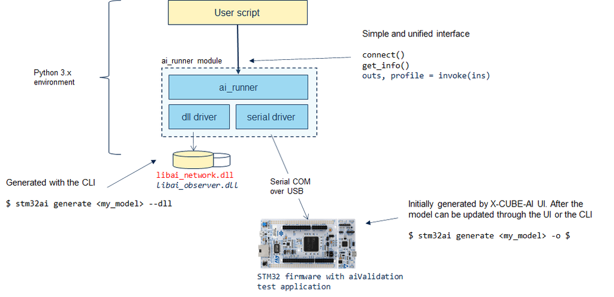

The generated X86 library is a self-content shared library including the generated c-model and the associated kernels. It is based on the same libraries which are used for the validation flow or for the C-base environment.

## Installation

`ai_runner` Python module is located in the `%X_CUBE_AI_DIR%/scripts` folder. Files can be copied in the user project or used directly from the pack.

Set the environment variable `PYTHONPATH` to tell Python (version 3.x) where to find the module.

```
$ export PYTHONPATH=%X_CUBE_AI_DIR%/script/ai_runner>:$PYTHONPATH
```

Minimal external Python module are requested. `requirements.txt` file:

```powershell
numpy
protobuf
pyserial==3.4
tqdm==4.50.2
```

## Getting started

**Generating the shared library**

```powershell
$ stm32ai generate <my_model> --dll
Neural Network Tools for STM32AI v1.5.1 (STM.ai v7.0.0)

 Generated files (6)
 ---------------------------------------------------------------------------------
 <workspace-directory-path>\inspector_network\workspace\generated\network_config.h
 <workspace-directory-path>\inspector_network\workspace\generated\network.h
 <workspace-directory-path>\inspector_network\workspace\generated\network.c
 <workspace-directory-path>\inspector_network\workspace\generated\network_data.h
 <workspace-directory-path>\inspector_network\workspace\generated\network_data.c
 <workspace-directory-path>\inspector_network\workspace\lib\libai_network.dll

Creating txt report file <output-directory-path>\network_generate_report.txt
```

The shared library `libai_network.dll` is created in the workspace directory. It can be used from this folder or copied in another folder (including the generic `libai_observer.dll` library which is requested for the advanced UCs). `libai_` name prefix should be always conserved.

**Info** — `--name/-n` option can be used to have different name file (ex. with `-n my_model`, `libai_my_model.dll` file is generated).

**Minimal code**

- see `%X_CUBE_AI_DIR%/script/ai_runner/example/minimal.py`.
- `desc` argument of the `connect()` method indicates a root location of the library file. The module searches from this location the first valid shared library (based on `libai_*` prefix) to bind it. User can provide the full path of library.

```python
from stm_ai_runner import AiRunner

runner = AiRunner()
runner.connect('file:stm32ai_ws')  # 'file' prefix can be omitted
runner.summary() # display the network/run-time information
...
outputs, _ = runner.invoke(inputs)  # invoke the model
```

Output of the `summary()` method:

```powershell
Summary "my_model" - ['my_model']
--------------------------------------------------------------------------------
inputs/outputs       : 1/1
input_1              : (1, 1, 1, 99), float32, 396 bytes, user
output_1             : (1, 1, 1, 5), float32, 20 bytes, user
n_nodes              : 6
compile_datetime     : Jun 15 2021 10:07:42 (Tue Jun 15 10:07:40 2021)
activations          : 192
weights              : 15560
macc                 : 4013
--------------------------------------------------------------------------------
runtime              : STM.AI 7.0.0 (Tools 7.0.0)
capabilities         : ['IO_ONLY', 'PER_LAYER', 'PER_LAYER_WITH_DATA']
device               : AMD64 Intel64 Family 6 Model 78 Stepping 3, GenuineIntel (Windows)
--------------------------------------------------------------------------------
```

The `invoke()` method requires a list of numpy array objects, one by input, with the expected c-shape and data type. The `get_input_infos()/get_output_infos()` methods can be used to retrieve the relevant information. They return a list of the dict (one by input/output), with the following keys:

| key | description |
| --- | --- |
| name | when available, name of the tensor, else pseudo `input_<idx>`/`output_<idx>` name is provided |
| shape | tuple with the c-shape definition |
| type | numpy type definition |
| scale | if quantized tensor, scale factor else None |
| zero-point | if quantized tensor, zero-point value else None |

The `invoke()` method returns a list of numpy array objects for the predicted values and a dict with the profiling information when available (see `%X_CUBE_AI_DIR%/script/ai_runner/example/ai_runner_test.py` to have more details).

**Connection to a STM32 aiValidation firmware**

If a STM32 board is flashed with an aiValidation test application which embeds one or multiple c-models, the `ai_runner` can be also used.

```python
from stm_ai_runner import AiRunner

runner = AiRunner()
runner.connect('serial')  # auto-detect mode
runner.summary() # display the network/run-time information
...
outputs, _ = runner.invoke(inputs)  # invoke the model
```

```powershell
Summary "network" - ['network']
--------------------------------------------------------------------------------
inputs/outputs       : 1/1
input_1              : (1, 1, 1, 99), float32, 396 bytes, user
output_1             : (1, 1, 1, 5), float32, 20 bytes, user
n_nodes              : 6
compile_datetime     : Jun 14 2021 11:06:17 (Mon Jun 14 11:04:52 2021)
activations          : 192
weights              : 15560
macc                 : 4013
--------------------------------------------------------------------------------
runtime              : Protocol 2.2 - STM.AI (/gcc) 7.0.0 (Tools 7.0.0)
capabilities         : ['IO_ONLY', 'PER_LAYER', 'PER_LAYER_WITH_DATA']
device               : 0x431 - STM32F411xC/E @100/100MHz fpu,art_lat=3,art_prefetch,art_icache,art_dcache
--------------------------------------------------------------------------------
```

## Examples

Location: `%X_CUBE_AI_DIR%/script/ai_runner/example/`

- `ai_runner_test.py` provides an example to use the `ai_runner` module including the profiling information

  ```powershell
  # Try to load the shared library located in the default location:  ./stm32ai_ws.
  # It displays a summary and performs two inferences with the random data.
  $ python ai_runner_test.py

  # As previously, but it performs a connection with a STM32 board (auto-detect mode)
  $ python ai_runner_test.py -d serial

  # Set the expected COM port and baudrate
  $ python ai_runner_test.py -d serial:COM6:115200

  # Request and report the execution time per layer
  $ python ai_runner_test.py -mode per_layer
  ```

- `tflite_test.py` provides a typical example to compare the outputs of the generated C-model against the predictions from the `tf.lite.Interpreter`.

  ```python
  outputs, _ = ai_runner.invoke(inputs)
  tf_outputs = tf_run(tf_interpreter, inputs)
  ```

- `mnist` provides a complete example with two scripts allowing to train a model (`train.py`) and to test (`test.py`) with the generated c-model.

## Typical errors

- No shared library found. `desc` designates a folder w/o valid shared library file.

  ```powershell
  invalid/unsupported "stm32ai_ws/:" descriptor
  ```

- Provided generated shared library is invalid. Error message indicates that the shared library has been generated w/o weights. This can appear when the `validate` command has been performed in the default `./stm32ai_ws/` directory.

  ```
  E801(HwIOError): No weights are available (1549912 bytes expected)
  ```

- STM32 board is not connected. auto-detect mode.

  ```
  E801(HwIOError): No SERIAL COM port detected (STM32 board is not connected!)
  ```

- COM port is already opened by another application (like TeraTerm(r) for example)

  ```
  E801(HwIOError): could not open port 'COM6': PermissionError(13, 'Access is denied.', None, 5)
  ```

- STM32 board is not flashed with a valid aiValidation firmware.

  ```
  E801(HwIOError): Invalid firmware - COM6:115200
  ```

Embedded Documentation - **How to run locally a c-model**  
X-CUBE-AI Expansion Package  
r1.0 - AI PLATFORM r7.0.0 (Embedded Inference Client API 1.1.0) - Command Line Interface r1.5.1

Information in this document is provided solely in connection with ST products. The contents of this document are subject to change without prior notice.  
© Copyright STMicroelectronics 2020. All rights reserved. www.st.com